# NYPD_Shooting_Incident

RockDeng

2024-01-04

### 1. Import data and get some basic understanding of the data.

- Load the data from CSV file into R Dataframe.
- Take a glimpse of the raw data.
- My data is downloaded from data.gov, please check here: https://catalog.data.gov/dataset/nypd-shooting-incident-data-historic

```r
# Import files
df <- read_csv("NYPD_Shooting_Incident_Data__Historic_.csv")
glimpse(df)
```

```
## Rows: 27,312
## Columns: 21
## $ INCIDENT_KEY            <dbl> 228798151, 137471050, 147998800, 146837977, 58…
## $ OCCUR_DATE              <chr> "05/27/2021", "06/27/2014", "11/21/2015", "10/…
## $ OCCUR_TIME              <time> 21:30:00, 17:40:00, 03:56:00, 18:30:00, 22:58…
## $ BORO                    <chr> "QUEENS", "BRONX", "QUEENS", "BRONX", "BRONX",…
## $ LOC_OF_OCCUR_DESC       <chr> NA, NA, NA, NA, NA, NA, NA, NA, NA, NA, NA, NA…
## $ PRECINCT                <dbl> 105, 40, 108, 44, 47, 81, 114, 81, 105, 101, 2…
## $ JURISDICTION_CODE       <dbl> 0, 0, 0, 0, 0, 0, 0, 0, 0, 0, 2, 0, 0, 0, 2, 2…
## $ LOC_CLASSFCTN_DESC      <chr> NA, NA, NA, NA, NA, NA, NA, NA, NA, NA, NA, NA…
## $ LOCATION_DESC           <chr> NA, NA, NA, NA, NA, NA, NA, NA, NA, "MULTI DWE…
## $ STATISTICAL_MURDER_FLAG <lgl> FALSE, FALSE, TRUE, FALSE, TRUE, TRUE, FALSE, …
## $ PERP_AGE_GROUP          <chr> NA, NA, NA, NA, "25-44", NA, NA, NA, NA, "25-4…
## $ PERP_SEX                <chr> NA, NA, NA, NA, "M", NA, NA, NA, NA, "M", NA, …
## $ PERP_RACE               <chr> NA, NA, NA, NA, "BLACK", NA, NA, NA, NA, "BLAC…
## $ VIC_AGE_GROUP           <chr> "18-24", "18-24", "25-44", "<18", "45-64", "25…
## $ VIC_SEX                 <chr> "M", "M", "M", "M", "M", "M", "M", "M", "M", "…
## $ VIC_RACE                <chr> "BLACK", "BLACK", "WHITE", "WHITE HISPANIC", "…
## $ X_COORD_CD              <dbl> 1058925.0, 1005028.0, 1007667.9, 1006537.4, 10…
## $ Y_COORD_CD              <dbl> 180924.0, 234516.0, 209836.5, 244511.1, 262189…
## $ Latitude                <dbl> 40.66296, 40.81035, 40.74261, 40.83778, 40.886…
## $ Longitude               <dbl> -73.73084, -73.92494, -73.91549, -73.91946, -7…
## $ Lon_Lat                 <chr> "POINT (-73.73083868899994 40.662964620000025)…
```

```r
dim(df)
```

```
## [1] 27312    21
```

```r
n = dim(df)[1]
n
```

```
## [1] 27312
```

As we can see the output from the above code. This data set has **27312** shooting incidents in total and **21** columns.

- Next, let’s check out the meaning of each column or variable.

| Column | Description |
| --- | --- |
| INCIDENT_KEY | Randomly generated persistent ID for each arrest |
| OCCUR_DATE | Exact date of the shooting incident |
| OCCUR_TIME | Exact time of the shooting incident |
| BORO | Borough where the shooting incident occurred |
| LOC_OF_OCCUR_DESC | NA |
| PRECINCT | Precinct where the shooting incident occurred |
| JURISDICTION_CODE | Jurisdiction where the shooting incident occurred. |
| LOC_CLASSFCTN_DESC | NA |
| LOCATION_DESC | Location of the shooting incident |
| STATISTICAL_MURDER_FLAG | Shooting resulted in the victim’s death which would be counted as a murder |
| PERP_AGE_GROUP | Perpetrator’s age within a category |
| PERP_SEX | Perpetrator’s sex description |
| PERP_RACE | Perpetrator’s race description |
| VIC_AGE_GROUP | Victim’s age within a category |
| VIC_SEX | Victim’s sex description |
| VIC_RACE | Victim’s race description |
| X_COORD_CD | Midblock X-coordinate for New York State Plane Coordinate System, Long Island Zone, NAD 83, units feet (FIPS 3104) |
| Y_COORD_CD | Midblock Y-coordinate for New York State Plane Coordinate System, Long Island Zone, NAD 83, units feet (FIPS 3104) |
| Latitude | Latitude coordinate for Global Coordinate System, WGS 1984, decimal degrees (EPSG 4326) |
| Longitude | Longitude coordinate for Global Coordinate System, WGS 1984, decimal degrees (EPSG 4326) |
| Lon_Lat | Combination of Latitude and Longtitude |

#### State the Purpose

Try to find the reasons and key factors that cause the shooting cases, so as to help law enforcement and the government to adjust policies and improve the current situation.

### 2. Tidying and Transforming Data

- Tidying the data involves cleaning up column names, dealing with missing values, and ensuring that the data is in a format suitable for analysis.
- Transformation typically involves filtering data, creating new variables, and summarizing it to prepare for further analysis.

#### 2.1 Convert the columns to convenient data type

- Conver the OCCUR_DATE variable from date string to date data type

```r
#glimpse(df)
# Convert OCCUR_DATE from string to date format
df$OCCUR_DATE = as.Date(df$OCCUR_DATE, format = "%m/%d/%Y")
```

#### 2.2 Remove duplicated columns or those won’t be userful for modeling

```r
# columns before removing
print(colnames(df))
```

```
##  [1] "INCIDENT_KEY"            "OCCUR_DATE"
##  [3] "OCCUR_TIME"              "BORO"
##  [5] "LOC_OF_OCCUR_DESC"       "PRECINCT"
##  [7] "JURISDICTION_CODE"       "LOC_CLASSFCTN_DESC"
##  [9] "LOCATION_DESC"           "STATISTICAL_MURDER_FLAG"
## [11] "PERP_AGE_GROUP"          "PERP_SEX"
## [13] "PERP_RACE"               "VIC_AGE_GROUP"
## [15] "VIC_SEX"                 "VIC_RACE"
## [17] "X_COORD_CD"              "Y_COORD_CD"
## [19] "Latitude"                "Longitude"
## [21] "Lon_Lat"
```

```r
# Example: Removing columns
df <- df %>%
  select(-INCIDENT_KEY, -LOC_OF_OCCUR_DESC, -LOC_CLASSFCTN_DESC, -LOCATION_DESC, -X_COORD_CD, -Y_COORD_CD, -Latitude, -Longitude, -Lon_Lat)

# columns after removing
print(colnames(df))
```

```
##  [1] "OCCUR_DATE"              "OCCUR_TIME"
##  [3] "BORO"                    "PRECINCT"
##  [5] "JURISDICTION_CODE"       "STATISTICAL_MURDER_FLAG"
##  [7] "PERP_AGE_GROUP"          "PERP_SEX"
##  [9] "PERP_RACE"               "VIC_AGE_GROUP"
## [11] "VIC_SEX"                 "VIC_RACE"
```

#### 2.3 Checkout and handle NA values

```r
summary(df)
```

```
##    OCCUR_DATE          OCCUR_TIME           BORO              PRECINCT
##  Min.   :2006-01-01   Length:27312      Length:27312       Min.   :  1.00
##  1st Qu.:2009-07-18   Class1:hms        Class :character   1st Qu.: 44.00
##  Median :2013-04-29   Class2:difftime   Mode  :character   Median : 68.00
##  Mean   :2014-01-06   Mode  :numeric                       Mean   : 65.64
##  3rd Qu.:2018-10-15                                        3rd Qu.: 81.00
##  Max.   :2022-12-31                                        Max.   :123.00
##
##  JURISDICTION_CODE STATISTICAL_MURDER_FLAG PERP_AGE_GROUP
##  Min.   :0.0000    Mode :logical           Length:27312
##  1st Qu.:0.0000    FALSE:22046             Class :character
##  Median :0.0000    TRUE :5266              Mode  :character
##  Mean   :0.3269
##  3rd Qu.:0.0000
##  Max.   :2.0000
##  NA's   :2
##    PERP_SEX          PERP_RACE         VIC_AGE_GROUP        VIC_SEX
##  Length:27312       Length:27312       Length:27312       Length:27312
##  Class :character   Class :character   Class :character   Class :character
##  Mode  :character   Mode  :character   Mode  :character   Mode  :character
##
##
##
##
##    VIC_RACE
##  Length:27312
##  Class :character
##  Mode  :character
##
##
##
##
```

- We can find out that the categorical variables didn’t have NA value.
- Do they really have no NA, or the NA values just hide in the strings, let’s find out lately.

##### 2.2.1 Checkout NA values in VIC_AGE_GROUP

```r
# Convert category columns to factors
unique(df$VIC_AGE_GROUP)
```

```
## [1] "18-24"   "25-44"   "<18"     "45-64"   "65+"     "UNKNOWN" "1022"
```

```r
df %>%
  filter(VIC_AGE_GROUP %in% c("UNKNOWN")) %>%
  count() ->
  vic_age_na_count

vic_age_na_count
```

```
## # A tibble: 1 × 1
##       n
##   <int>
## 1    61
```

```r
# Pecentage of na values in this variable
(vic_age_na_count / n) * 100
```

```
##          n
## 1 0.223345
```

```r
# remove those UNKNOWN values
df <- subset(df, VIC_AGE_GROUP != "UNKNOWN")

unique(df$VIC_AGE_GROUP)
```

```
## [1] "18-24" "25-44" "<18"   "45-64" "65+"   "1022"
```

##### 2.2.2 Checkout NA values in VIC_SEX

U should stand for “undefined”, let’s set it to NA.

```r
unique(df$VIC_SEX)
```

```
## [1] "M" "F" "U"
```

```r
df %>%
  filter(VIC_SEX %in% c("U")) %>%
  count() ->
  vic_sex_na_count

vic_sex_na_count
```

```
## # A tibble: 1 × 1
##       n
##   <int>
## 1     6
```

```r
# Pecentage of na values in this variable
(vic_sex_na_count / n) * 100
```

```
##            n
## 1 0.02196837
```

```r
# remove those UNKNOWN values
df <- subset(df, VIC_SEX != "U")

unique(df$VIC_SEX)
```

```
## [1] "M" "F"
```

##### 2.2.3 Checkout NA values in VIC_RACE

```r
unique(df$VIC_RACE)
```

```
## [1] "BLACK"                          "WHITE"
## [3] "WHITE HISPANIC"                 "BLACK HISPANIC"
## [5] "ASIAN / PACIFIC ISLANDER"       "UNKNOWN"
## [7] "AMERICAN INDIAN/ALASKAN NATIVE"
```

```r
df %>%
  filter(VIC_RACE %in% c("UNKNOWN")) %>%
  count() ->
  vic_race_na_count

vic_race_na_count
```

```
## # A tibble: 1 × 1
##       n
##   <int>
## 1    48
```

```r
# Pecentage of na values in this variable
(vic_race_na_count / n) * 100
```

```
##           n
## 1 0.1757469
```

```r
# remove those UNKNOWN values
df <- subset(df, VIC_RACE != "UNKNOWN")

unique(df$VIC_RACE)
```

```
## [1] "BLACK"                          "WHITE"
## [3] "WHITE HISPANIC"                 "BLACK HISPANIC"
## [5] "ASIAN / PACIFIC ISLANDER"       "AMERICAN INDIAN/ALASKAN NATIVE"
```

##### 2.2.4 Checkout NA values in PERP_AGE_GROUP

```r
unique(df$PERP_AGE_GROUP)
```

```
##  [1] NA        "25-44"   "UNKNOWN" "18-24"   "45-64"   "<18"     "65+"
##  [8] "940"     "(null)"  "224"     "1020"
```

```r
df %>%
  filter(PERP_AGE_GROUP %in% c(NA, "UNKNOWN", "(null)")) %>%
  count() ->
  perp_age_na_count

perp_age_na_count
```

```
## # A tibble: 1 × 1
##       n
##   <int>
## 1 13100
```

```r
# Pecentage of na values in this variable
(perp_age_na_count / n) * 100
```

```
##          n
## 1 47.96426
```

```r
# Too many na values, remove this column
df <- subset(df, select = -PERP_AGE_GROUP)

print(colnames(df))
```

```
##  [1] "OCCUR_DATE"              "OCCUR_TIME"
##  [3] "BORO"                    "PRECINCT"
##  [5] "JURISDICTION_CODE"       "STATISTICAL_MURDER_FLAG"
##  [7] "PERP_SEX"                "PERP_RACE"
##  [9] "VIC_AGE_GROUP"           "VIC_SEX"
## [11] "VIC_RACE"
```

- The rate of NA value in this variable is really high, and almost half of the observations are NA here.
- Therefore this variable might not useful for modeling, otherwise we need to remove almost half of the dataset.

##### 2.2.5 Checkout NA values in PERP_SEX

- Like the previous variable PERP_AGE_GROUP, the rate of NA values in this variable is almost same as the PERP_AGE_GROUP.

```r
unique(df$PERP_SEX)
```

```
## [1] NA       "M"      "U"      "F"      "(null)"
```

```r
df %>%
  filter(PERP_SEX %in% c(NA, "(null)", "U")) %>%
  count() ->
  perp_sex_na_count
perp_sex_na_count
```

```
## # A tibble: 1 × 1
##       n
##   <int>
## 1 11419
```

```r
# Pecentage of na values in this variable
(perp_sex_na_count / n) * 100
```

```
##          n
## 1 41.80946
```

```r
# Too many na values, remove this column
df <- subset(df, select = -PERP_SEX)

print(colnames(df))
```

```
##  [1] "OCCUR_DATE"              "OCCUR_TIME"
##  [3] "BORO"                    "PRECINCT"
##  [5] "JURISDICTION_CODE"       "STATISTICAL_MURDER_FLAG"
##  [7] "PERP_RACE"               "VIC_AGE_GROUP"
##  [9] "VIC_SEX"                 "VIC_RACE"
```

##### 2.2.6 Checkout NA values in PERP_RACE

- NA rate still almost equal to 0.5 for this variable

```r
unique(df$PERP_RACE)
```

```
## [1] NA                               "BLACK"
## [3] "UNKNOWN"                        "BLACK HISPANIC"
## [5] "ASIAN / PACIFIC ISLANDER"       "WHITE HISPANIC"
## [7] "WHITE"                          "(null)"
## [9] "AMERICAN INDIAN/ALASKAN NATIVE"
```

```r
df %>%
  filter(PERP_RACE %in% c(NA, "UNKNOWN", "(null)")) %>%
  count() ->
  perp_race_na_count

perp_race_na_count
```

```
## # A tibble: 1 × 1
##       n
##   <int>
## 1 11755
```

```r
# Pecentage of na values in this variable
(perp_race_na_count / n) * 100
```

```
##          n
## 1 43.03969
```

```r
# Too many na values, remove this column
df <- subset(df, select = -PERP_RACE)

print(colnames(df))
```

```
## [1] "OCCUR_DATE"              "OCCUR_TIME"
## [3] "BORO"                    "PRECINCT"
## [5] "JURISDICTION_CODE"       "STATISTICAL_MURDER_FLAG"
## [7] "VIC_AGE_GROUP"           "VIC_SEX"
## [9] "VIC_RACE"
```

```r
unique(df$JURISDICTION_CODE)
```

```
## [1]  0  2  1 NA
```

```r
df %>%
  filter(JURISDICTION_CODE %in% c(NA, "UNKNOWN", "(null)")) %>%
  count() ->
  JURISDICTION_CODE_na_count

JURISDICTION_CODE_na_count
```

```
## # A tibble: 1 × 1
##       n
##   <int>
## 1     2
```

```r
# Pecentage of na values in this variable
(JURISDICTION_CODE_na_count / n) * 100
```

```
##             n
## 1 0.007322789
```

```r
# remove rows with NA
df <- subset(df, JURISDICTION_CODE != "NA")

unique(df$JURISDICTION_CODE)
```

```
## [1] 0 2 1
```

##### 2.2.8 Checkout NA values in remain columns

```r
unique(df$BORO)
```

```
## [1] "QUEENS"        "BRONX"         "BROOKLYN"      "MANHATTAN"
## [5] "STATEN ISLAND"
```

```r
unique(df$PRECINCT)
```

```
##  [1] 105  40 108  44  47  81 114 101  23  75  71  50  78  30  73  84  90  60  48
## [20] 106  28  79 120  34 103  13  83  49  67  52  63 110  41  42  43  26  77  25
## [39]  76  14 113  24  69  46  32  45   9  62   7  33 104  61  72  88  70  10 102
## [58]  17 115 100   6 107   5 121  94 122  18 109  66  19   1 123  20  22 112  68
## [77] 111
```

```r
unique(df$STATISTICAL_MURDER_FLAG)
```

```
## [1] FALSE  TRUE
```

```r
# Check the number of NA values
sum(is.na(df$OCCUR_TIME))  # Count NA in OCCUR_TIME
```

```
## [1] 0
```

```r
sum(is.na(df$OCCUR_DATE))  # Count NA in OCCUR_DATE
```

```
## [1] 0
```

```r
# print remain colunms after data clean
print(colnames(df))
```

```
## [1] "OCCUR_DATE"              "OCCUR_TIME"
## [3] "BORO"                    "PRECINCT"
## [5] "JURISDICTION_CODE"       "STATISTICAL_MURDER_FLAG"
## [7] "VIC_AGE_GROUP"           "VIC_SEX"
## [9] "VIC_RACE"
```

### 3. Exploratory Data Analysis and Visualization

#### 3.1 Explore the case distribution in different characteristics of victim

```r
# Check out the victims
unique(df$VIC_AGE_GROUP)
```

```
## [1] "18-24" "25-44" "<18"   "45-64" "65+"   "1022"
```

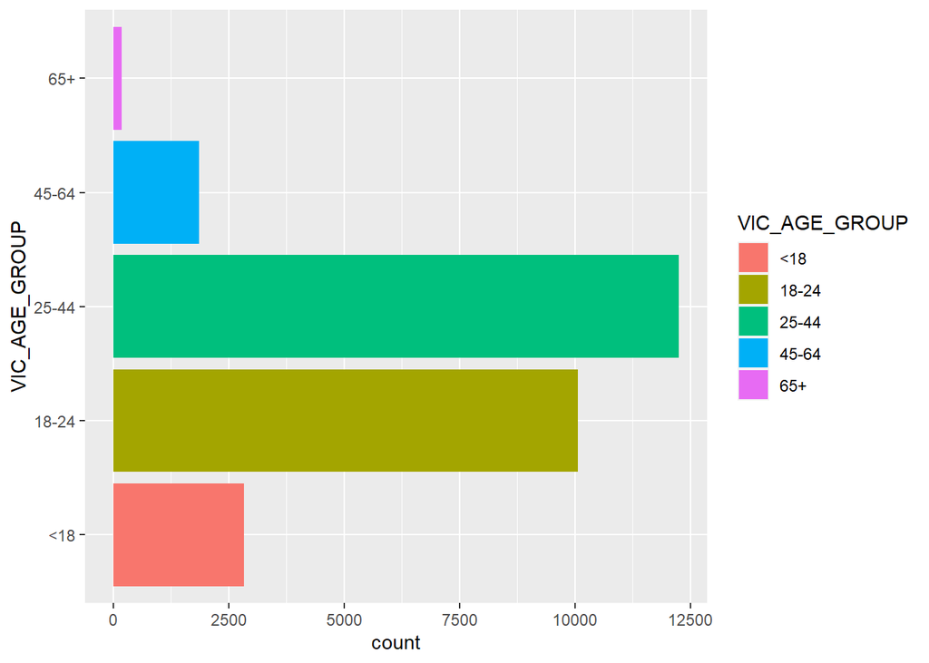

```r
df %>%
  filter(VIC_AGE_GROUP != "1022") ->
  df


# Define a function to analyze and visualize a category column.
analyze_category <- function(data, col_name){
    ggplot(data) +
    geom_bar(aes_string(y = col_name, fill = col_name))
}

# Analysis for victims
analyze_category(df, "VIC_AGE_GROUP")
```

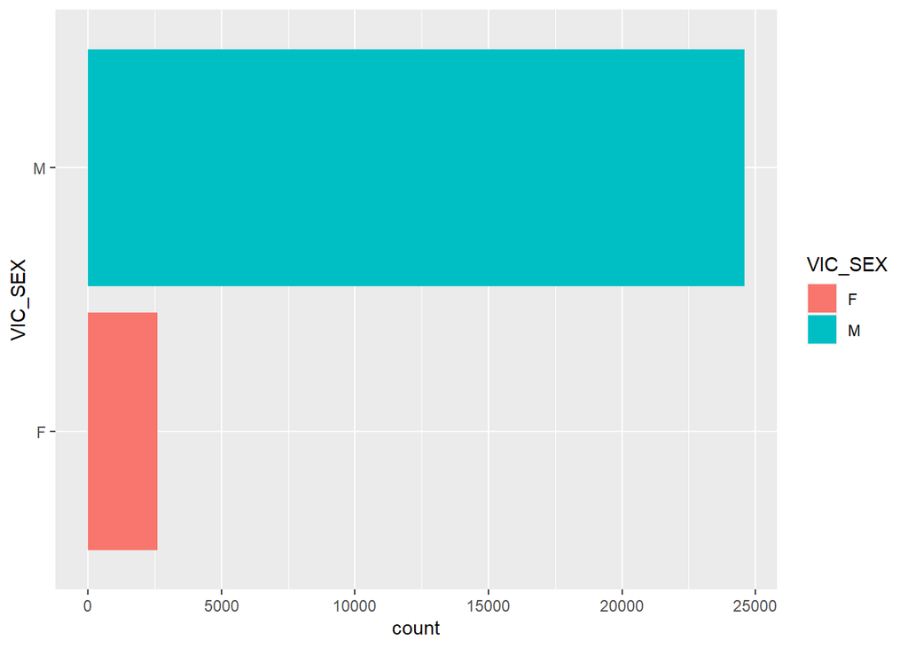

```r
analyze_category(df, "VIC_SEX")
```

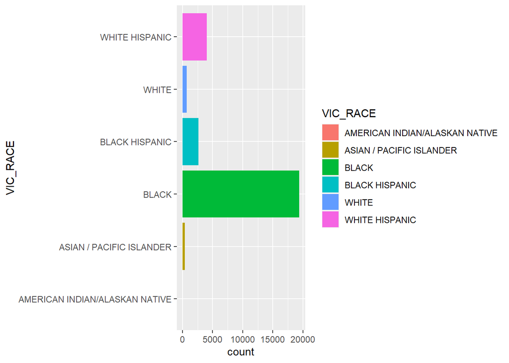

```r
analyze_category(df, "VIC_RACE")
```

#### 3.2 Geospatial anaylysis on this dataset

- Brooklyn and Bronx have the highest probability of incident occurrence
- And public safety resources should probably be directed toward these two areas.

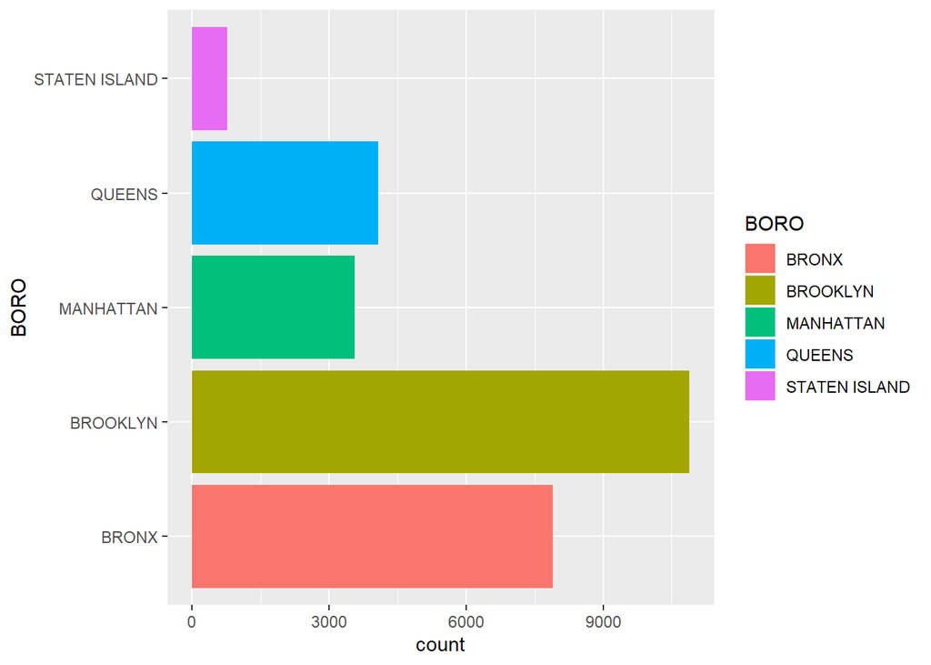

```r
# Analysis geographically
analyze_category(df, "BORO")
```

#### 3.3 Temporal analysis on this dataset

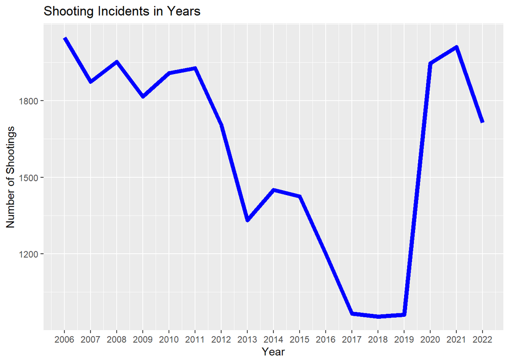

```r
yearly_data <- df %>%
  mutate(year = as.integer(year(OCCUR_DATE))) %>%
  group_by(year) %>%
  summarize(n = n(), .groups = 'drop')

ggplot(yearly_data, aes(x = year, y = n)) +
  geom_line(color = "blue", size = 2) +
  labs(title = "Shooting Incidents in Years",
       x = "Year",
       y = "Number of Shootings") +
  scale_x_continuous(breaks = seq(min(yearly_data$year), max(yearly_data$year), by = 1)) +
  scale_y_continuous(limits = c(min(yearly_data$n), max(yearly_data$n)),
                       breaks = seq(0, max(yearly_data$n), by = 300)) +
  annotate("text", x = max(yearly_data$year), y = 0, label = "Start", vjust = -1)
```

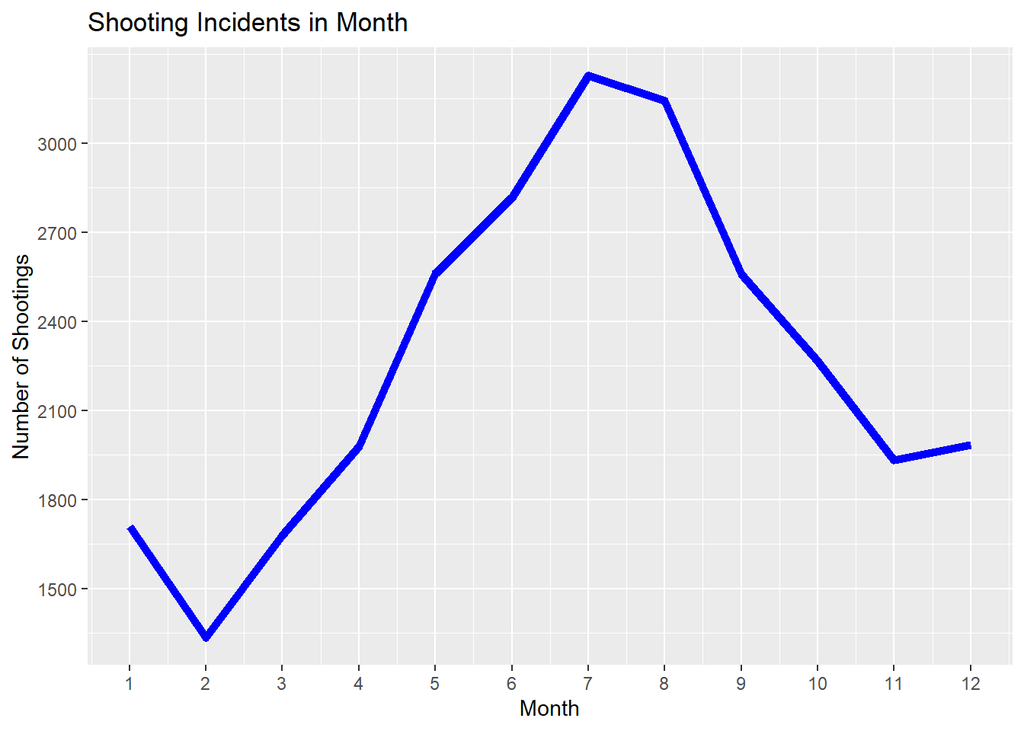

```r
monthly_data <- df %>%
  mutate(month = as.integer(month(OCCUR_DATE))) %>%
  group_by(month) %>%
  summarize(n = n(), .groups = 'drop')

ggplot(monthly_data, aes(x = month, y = n)) +
  geom_line(color = "blue", size = 2) +
  labs(title = "Shooting Incidents in Month",
       x = "Month",
       y = "Number of Shootings") +
  scale_x_continuous(breaks = seq(min(monthly_data$month), max(monthly_data$month), by = 1)) +
  scale_y_continuous(limits = c(min(monthly_data$n), max(monthly_data$n)),
                       breaks = seq(0, max(monthly_data$n), by = 300)) +
  annotate("text", x = max(monthly_data$month), y = 0, label = "Start", vjust = -1)
```

- Checking the plot of cases per month, the most shootings occur in July and August.
- There seems to be a correlation between the number of shootings and the temperature.

### 4. Modeling

```r
# Convert 'occur_date' to Date type and extract the year
df_t <- df %>%
  mutate(occur_date = as.Date(OCCUR_DATE, format="%m/%d/%Y"),
         occur_year = lubridate::year(OCCUR_DATE))

# Group the data by borough and year to summarize the number of shooting incidents
data_grouped <- df_t %>%
  group_by(BORO, occur_year) %>%
  summarise(shooting_count = n()) %>%
  ungroup()
head(data_grouped)
```

```
## # A tibble: 6 × 3
##   BORO  occur_year shooting_count
##   <chr>      <dbl>          <int>
## 1 BRONX       2006            568
## 2 BRONX       2007            530
## 3 BRONX       2008            517
## 4 BRONX       2009            523
## 5 BRONX       2010            523
## 6 BRONX       2011            571
```

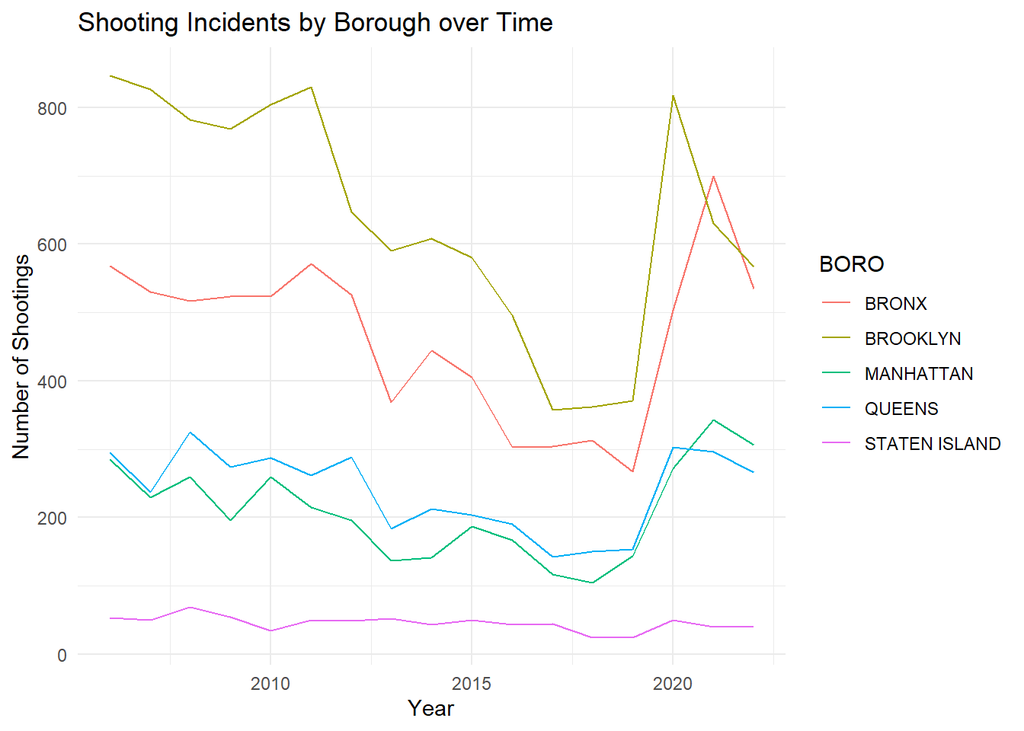

```r
ggplot(data_grouped, aes(x = occur_year, y = shooting_count, color = BORO)) +
  geom_line() +
  labs(title = "Shooting Incidents by Borough over Time",
       x = "Year",
       y = "Number of Shootings") +
  theme_minimal()
```

```r
# Create a linear model to see trends over time
model <- lm(shooting_count ~ occur_year + BORO, data = data_grouped)

# Print the summary of the model
summary(model)
```

```
##
## Call:
## lm(formula = shooting_count ~ occur_year + BORO, data = data_grouped)
##
## Residuals:
##      Min       1Q   Median       3Q      Max
## -263.285  -46.917   -2.471   44.665  282.001
##
## Coefficients:
##                    Estimate Std. Error t value Pr(>|t|)
## (Intercept)       13936.904   4335.084   3.215  0.00189 **
## occur_year           -6.689      2.152  -3.108  0.00262 **
## BOROBROOKLYN        175.529     33.346   5.264 1.18e-06 ***
## BOROMANHATTAN      -255.353     33.346  -7.658 4.03e-11 ***
## BOROQUEENS         -225.294     33.346  -6.756 2.18e-09 ***
## BOROSTATEN ISLAND  -419.353     33.346 -12.576  < 2e-16 ***
## ---
## Signif. codes:  0 '***' 0.001 '**' 0.01 '*' 0.05 '.' 0.1 ' ' 1
##
## Residual standard error: 97.22 on 79 degrees of freedom
## Multiple R-squared:  0.8355, Adjusted R-squared:  0.8251
## F-statistic: 80.23 on 5 and 79 DF,  p-value: < 2.2e-16
```

### 5. Conclusion

This report analyzed the NYPD Shooting Incident Data to explore trends in shooting incidents across various boroughs in New York City over time. The primary objective was to identify whether there are discernible trends in the number of shootings across boroughs and determine if certain boroughs are more prone to shooting incidents.

#### Possible Sources of Bias

While this analysis offers valuable insights, several sources of bias must be considered. Firstly, the dataset may contain reporting biases, where certain incidents might not have been reported or properly recorded. Secondly, missing data, such as incomplete incident details or incorrect categorization of boroughs, could have skewed the results.

#### Personal Bias and Mitigation

As a researcher, my personal bias may stem from my prior knowledge of New York City and assumptions regarding which boroughs might have higher crime rates. To mitigate this bias, I relied solely on the data-driven trends, avoiding assumptions based on my preconceived notions of the city. Additionally, I conducted an objective and systematic analysis of all boroughs rather than focusing disproportionately on any specific borough.

#### Future Work

This analysis is limited by the scope of the available dataset, which focuses solely on recorded shooting incidents. Future analyses should consider integrating socio-economic data, police activity records, and crime reporting patterns to offer a more comprehensive understanding of the factors driving these incidents.